# PeoplesChoiceHitChart2017

# Who’s on everyone’s 2017 “hit list”?

At the end of the year, everyone is making lists. And radio stations are no exceptions.  
Many of our radio stations have a weekly “people’s choice” music chart. Throughout the week, people submit their top 3 recent songs, and every week those votes turn into a music chart. At the end of the year, they collapse all those weekly charts into a larger one covering the entire year.

I find this one quite interesting: it’s not dependent on what music people buy, it’s determined by what the audience of that station wants to hear. So what are the differences between these stations? And do they match up with what I would expect?

What was also quite intriguing: in Dutch we call it a *hit lijst* and if you translate that word for word you get: *hit list*. Which at least one radio station seems to do… When I think of the word hit list, music is not really what comes to mind, but hey, let’s roll with it: which artists are on their ‘hit lists’?

## About the data

I took 4 different radio stations:

- Radio 1: The most serious of our public broadcast stations. It’s aimed at current affairs, politics, news, … When I think of Radio 1 music, I think of Leonard Cohen, Marianne Faithfull, Nathaniel Ratecliff and Elbow.
- Studio Brussels: Formerly known as the “rock station”, but now it’s really a mix of modern rock, pop, indie & dance music.
- MNM: Described as the “contemporary hit radio station” of the public broadcast organisation
- Q music: A commercial “contemporary hit radio station”

There is one major and annoying drawback in this dataset: Studio Brussels does a top 30, while all the others do a top 100.

Loading all the packages needed:

```r
#for scraping
library(rvest)
library(xml2)

#for cleanup and data manipulation
library(dplyr)
library(tidyr)

#for graphing
library(ggplot2)
```

## Web Scraping Etiquette

Before starting the scrape, I wanted to make sure that I was allowed to do so using the rOpenSci robotstxt package:

```r
#Webscraping etiquette: am i allowed to scrape this site?
robotstxt::paths_allowed("https://stubru.be/music/arcadefireopeenindeafrekening2017")
robotstxt::paths_allowed("https://mnm.be/mnm50/dezesongstemdejijhetafgelopenjaartvaakstdemnm50")
robotstxt::paths_allowed("https://radio1.be/vox-100-de-lijst-2017")
robotstxt::paths_allowed("https://qmusic.be/hitlijsten/favoriete-100-2017")
```

```
## [1] TRUE
## [1] TRUE
## [1] TRUE
## [1] TRUE
```

## Bad luck with the standard scraping procedures…

A quick search showed no APIs for any of these websites, so I started with `rvest` and the usual CSS nodes routine. Unfortunately no CSS element or XPATH gave me any useful information.

```r
#usual method
read_html("https://stubru.be/music/arcadefireopeenindeafrekening2017") %>%
  html_nodes(css=".song-title")
```

```
## {xml_nodeset (0)}
```

The issue is that the website is rendered through Javascript, and R is scraping the website before all the content is loaded. After a bit of googling I found [a tutorial](https://www.datacamp.com/community/tutorials/scraping-javascript-generated-data-with-r) that had all the answers I needed.

## Scraping Javascript rendered websites

Through `phantomJS` you can create a representation of the website after Javascript loaded all the data. Afterwards you can scrape the local version.  
I opened a normal notepad and saved the following as `scrape_stubu.js`:

```
var webPage = require('webpage');
var page = webPage.create();

var fs = require('fs');
var path = 'scrape_stubru.html'

page.open('https://stubru.be/music/arcadefireopeenindeafrekening2017', function (status) {
  var content = page.content;
  fs.write(path,content,'w')
  phantom.exit();
});
```

Next, you use a `system` command in R to run the script and return a local html version. You need `phantomJS` installed to do this, but you can easily install it form [here](http://phantomjs.org/download.html).

```r
#generate local copies of all required websites
system("./phantomjs/bin/phantomjs scrape_stubru.js")
system("./phantomjs/bin/phantomjs scrape_qmusic.js")
system("./phantomjs/bin/phantomjs scrape_mnm.js")
```

## Scraping the data

The javascript rendered websites all had quite similar structures, so I wrote a function to extract the ranking, artist and title from the website and return it as a dataframe.

```r
#function to scrap info
scrape_music <- function(html, css_artist, css_title, css_ranking) {
  html_page <- read_html(html)

  #extracting song info
  artist <- html_page %>%
    html_nodes(css = css_artist) %>%
    html_text() %>%
    tolower()

  #extracting artist info
  title <- html_page %>%
    html_nodes(css = css_title) %>%
    html_text() %>%
    tolower()

  #extracting ranking
  ranking <- html_page %>%
    html_nodes(css = css_ranking) %>%
    html_text() %>%
    as.numeric()

  #making a dataframe
  df <- data.frame(ranking, artist, title, stringsAsFactors = FALSE)
  return(df)
}
```

Using the function above, three radio stations were easily scraped. Two of them needed no additional clean-up. Only Qmusic needed some extra cleanup to remove a few “/n” signs.

```r
#scraping studio brussels
stubru <- scrape_music(html = "scrape_stubru.html", css_artist = ".song-title",
                            css_title = ".song-name", css_ranking=".song-position")
colnames(stubru) <- c("stubru_ranking", "artist", "title")

#scraping mnm
mnm <- scrape_music(html = "scrape_mnm.html", css_artist = ".song-name",
                       css_title = ".song-title", css_ranking=".song-position")
colnames(mnm) <- c("mnm_ranking", "artist", "title")

#scraping mnm
qmusic <- scrape_music(html = "scrape_qmusic.html", css_artist = ".title-bar",
                    css_title = ".subtitle", css_ranking=".hitlist-position")
colnames(qmusic) <- c("qmusic_ranking", "artist", "title")
qmusic$title <- gsub("\n", "", qmusic$title)
qmusic$artist <- gsub("\n", "", qmusic$title)
```

Radio 1 was by far the trickiest. Even after rendering it through `phantomJS` it kept returning no content in any of the CSS nodes referring to the table containing the hit chart. Digging in the `inspect element` view of the brower I found out that the table was sourced from yet another page, but even on that page phantomJS didn’t do the job. (If anyone can tell me why, please do!)  
Luckily a couple of curses later, I discovered an API link in the source code of the webpage.  
I was about to skip Radio 1 all together, but there it was…

```r
library(jsonlite)
content2 <- fromJSON("https://hitlijst.vrt.be/api/lists/3594.json")
str(content2$songs, max.level=1)
```

```
## 'data.frame':    100 obs. of  29 variables:
##  $ id            : chr  "119886" "69697" "91329" "45172" ...
##  $ main_artist   : chr  "40349" "33" "2402" "17910" ...
##  $ title         : chr  "That's not how dreams are made" "Shape of you" "Holding on" "Habibi" ...
##  $ lyrics        : chr  "" "The club isn't the best place to find a lover\r\nSo the bar is where I go\r\nMe and my friends at the table doi"| __truncated__ "" "Something hides in every night\r\nBrings desire from the deep\r\nAnd with it comes a burning light\r\nTo keep u"| __truncated__ ...
##  $ audio_url     : chr  "https://p.scdn.co/mp3-preview/e8ac408c76f326951846526c360ac9563e753abb?cid=37769582dd7d4c3083f7caeeaab31f4f" "https://p.scdn.co/mp3-preview/84462d8e1e4d0f9e5ccd06f0da390f65843774a2?cid=37769582dd7d4c3083f7caeeaab31f4f" "https://p.scdn.co/mp3-preview/8fb69098e0ad6576048aa3…
##  $ image_url     : chr  "https://hitlijst.vrt.be/sites/default/files/styles/large/public/songs/covers/119886.jpg?itok=a2jYJCZs" "https://hitlijst.vrt.be/sites/default/files/styles/large/public/songs/covers/69697.jpg?itok=k6M3A1IR" "https://hitlijst.vrt.be/sites/default/files/styles/large/public/s…
##  $ youtube_url   : chr  NA "https://www.youtube.com/embed/JGwWNGJdvx8" NA "https://www.youtube.com/embed/p1YVkwr15Y4" ...
##  $ itunes_buy    : logi  NA NA NA NA NA NA ...
##  $ release_date  : logi  NA NA NA NA NA NA ...
##  $ distributor_id: logi  NA NA NA NA NA NA ...
##  $ label_id      : logi  NA NA NA NA NA NA ...
##  $ language_id   : chr  "" "" "" "" ...
##  $ enriched      : chr  "1" "1" "1" "1" ...
##  $ custom        : chr  NA NA NA NA ...
##  $ modified_at   : chr  "1514814142" "1512662787" "1514814163" "1490104343" ...
##  $ created_at    : chr  "1513094440" "1483679026" "1496740901" "1480075914" ...
##  $ uid           : chr  "1" "9" "1" "1" ...
##  $ import_id     : chr  NA NA NA NA ...
##  $ image_id      : chr  "60581" "43970" "60582" "44162" ...
##  $ spotify_id    : chr  "4i6LmGukU7aH3mrDmjPAtE" "0FE9t6xYkqWXU2ahLh6D8X" "2h5CXy8Pme1lTY3CUAEI1i" "0yfCofxWnDGApodzG8cu1x" ...
##  $ quote         : chr  "" "" "" "" ...
##  $ position      : int  1 2 3 4 5 6 7 8 9 10 ...
##  $ entity_id     : chr  "119886" "69697" "91329" "45172" ...
##  $ name          : chr  "Jasper Stevelinck" "Ed Sheeran" "War On Drugs" "Tamino" ...
##  $ song_id       : chr  "119886" "69697" "91329" "45172" ...
##  $ previous      : int  0 0 0 0 0 0 0 0 0 0 ...
##  $ weeksinlist   : int  1 17 1 15 1 20 17 14 17 21 ...
##  $ rank          :List of 100
##  $ image         : chr  "https://hitlijst.vrt.be/sites/default/files/styles/large/public/songs/covers/119886.jpg?itok=a2jYJCZs" "https://hitlijst.vrt.be/sites/default/files/styles/large/public/songs/covers/69697.jpg?itok=k6M3A1IR" "https://hitlijst.vrt.be/sites/default/files/styles/large/public/s…
```

```r
title <- tolower(content2$songs$title)
artist <- tolower(content2$songs$name)
radio1_ranking <- as.numeric(content2$songs$position)

radio1 <- data.frame(radio1_ranking, title, artist, stringsAsFactors = FALSE)
```

## Comparing the radio stations

I wrote a short function that compares the two dataframes via `semi_join()` and then pastes a short sentence together with `paste`. Not the most ingenious solution, but fast and useful enough.

## Radio 1

```
## [1] "Songs in common between Radio1 and Studio Brussels: 13 (out of 30)"
## [1] "Songs in common between Radio1 and MNM: 11"
## [1] "Songs in common between Radio1 and Qmusic: 9"
```

13 songs in common with Studio Brussels, and 5 of these are top 20 for both audiences. Nothing hugely unexpected here.

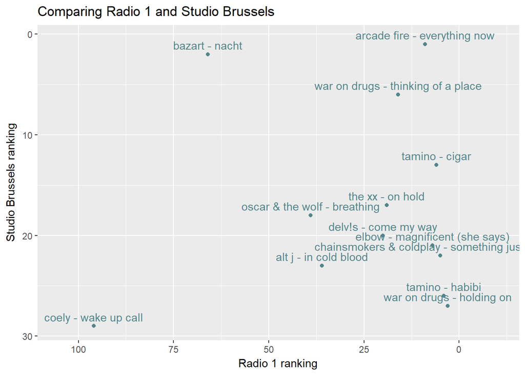

```r
#plotting stubru versus radio 1
radio1 %>%
  inner_join(stubru, by="title") %>%
  unite(combo, artist.x, title, sep=" - ") %>%
  ggplot(aes(x=radio1_ranking, y=stubru_ranking, label = combo))+
  geom_point(colour="cadetblue4") +
  scale_y_reverse(name = "Studio Brussels ranking") +
  scale_x_reverse(name = "Radio 1 ranking", limits=c(105,-10), breaks=c(0, 25, 50,75, 100)) +
  geom_text(vjust = 0, nudge_y = 0.5, colour="cadetblue4") +
  ggtitle("Comparing Radio 1 and Studio Brussels")
```

11 songs on both radio 1 and mnm: two of them are quite high on both: Ed Sheeran and The Chainsmokers & Coldplay.

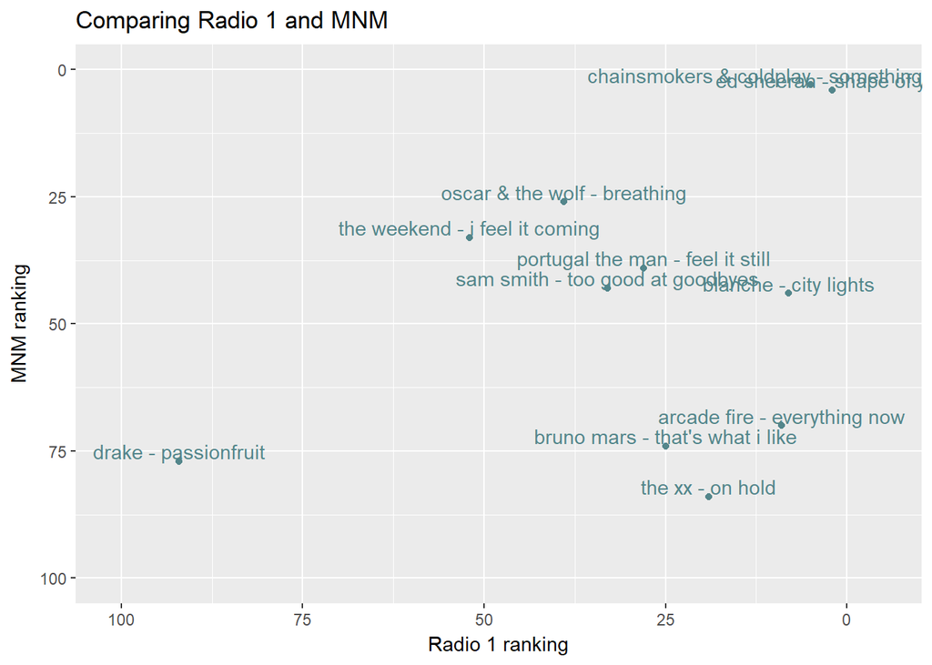

9 songs in common between radio1 and the commercial hit radio: again Ed sheeran and The Chainsmokers & Coldplay.

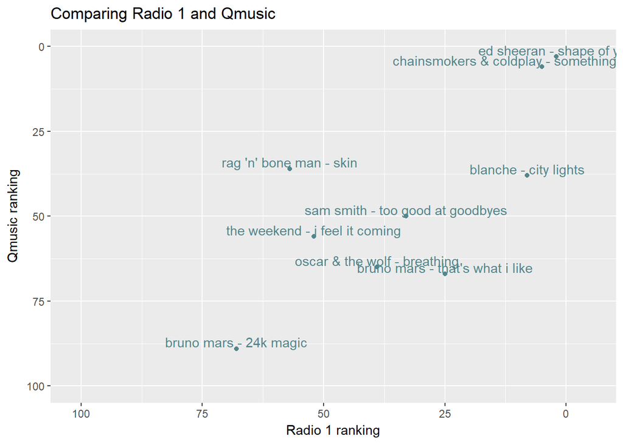

## Studio Brussels

As expected, there is most overlap between Studio Brussels and Radio1.

```
## [1] "Songs in common between Studio Brussels and Radio1: 13(out of 30)"
## [1] "Songs in common between Studio Brussels and MNM: 7(out of 30)"
## [1] "Songs in common between Studio Brussels and Qmusic: 5(out of 30)"
```

Versus the hitradios there are 5 to 7 songs in common. Ed Sheeran is launching quite a trend in that upper right corner.

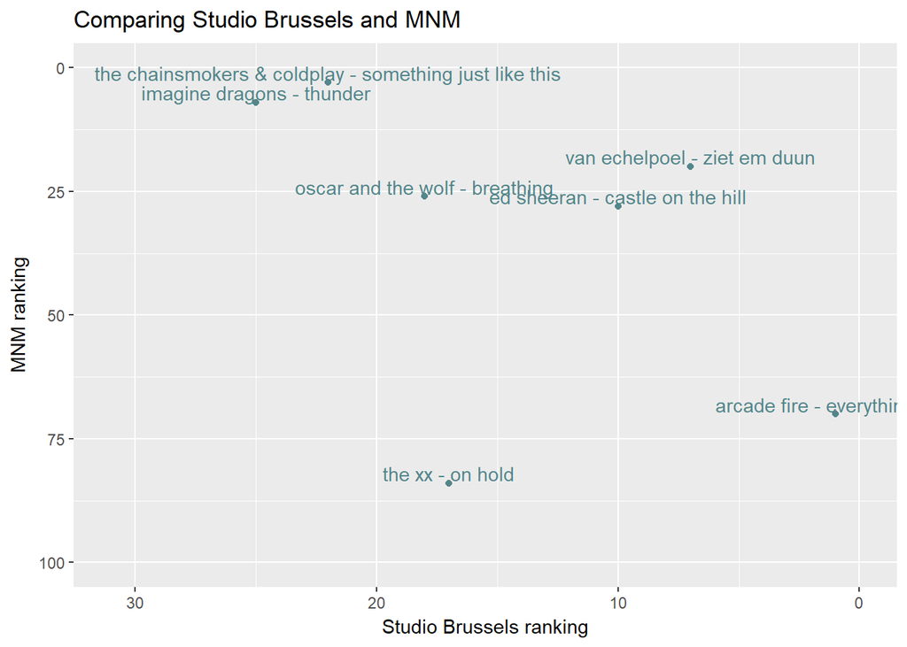

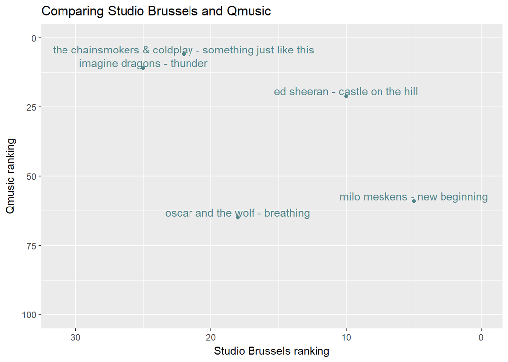

## MNM and Q-music

Lastly, both hit radios against each other: I’m expecting massive overlap between these two, but how massive exactly?  
Indeed a massive 61 songs in common.

```
## [1] "Songs in common between MNM and Qmusic: 61"
## [1] "Songs in common between MNM and Radio1: 11"
## [1] "Songs in common between MNM and Studio Brussels: 7"
## [1] "Songs in common between Qmusic and Radio1: 9"
## [1] "Songs in common between Qmusic and Studio Brussels: 5"
```

So much overlap, it’s hardly readable, and espcially the upper right corner is very populated, confirming that both audiences like the same 2017 songs.

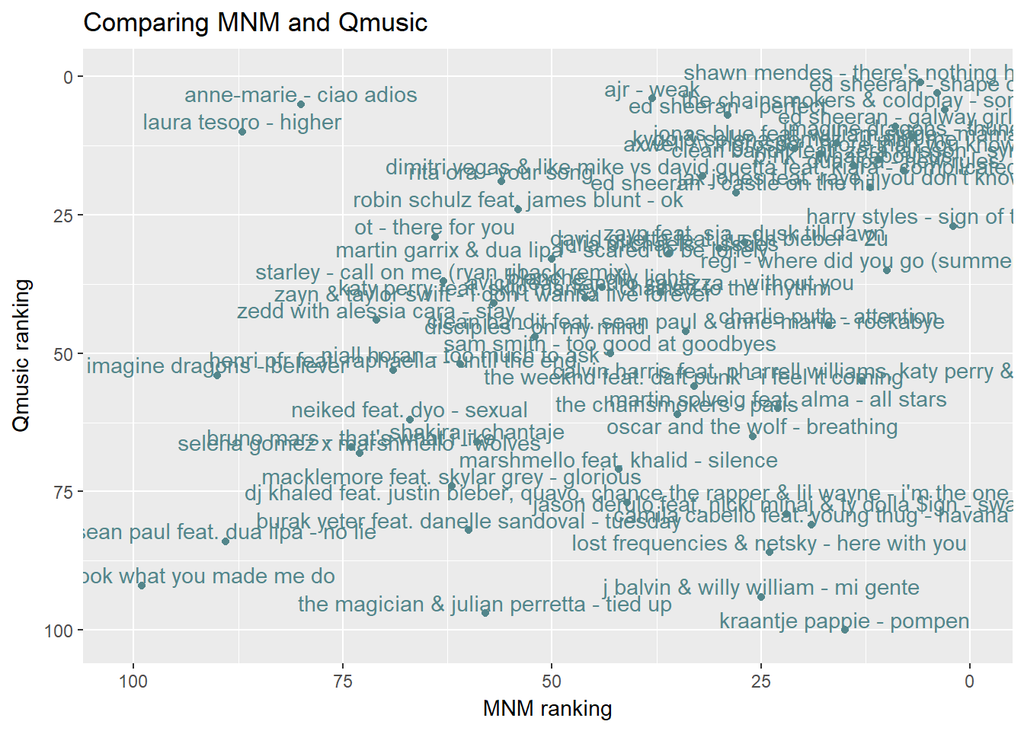

## The final hit list

```r
#the common hit list
stubru %>%
  inner_join(radio1, by="title") %>%
  inner_join(mnm, by="title") %>%
  inner_join(qmusic, by="title") %>%
  select(artist.x, title, radio1_ranking, stubru_ranking, mnm_ranking, qmusic_ranking) %>%
  knitr::kable(format="html", caption="Common songs on everyone's list",
               col.names = c("Artist", "Title", "Radio1 #",
                             "Studio Brussels #", "MNM #", "Qmusic #")) %>%
  kableExtra::kable_styling(bootstrap_options=c("hover", "bordered"))
```

Common songs on everyone’s list

| Artist | Title | Radio1 # | Studio Brussels # | MNM # | Qmusic # |
| --- | --- | --- | --- | --- | --- |
| oscar and the wolf | breathing | 39 | 18 | 26 | 65 |
| the chainsmokers & coldplay | something just like this | 5 | 22 | 3 | 6 |

```r
#amongst with a longer hit list
radio1 %>%
  inner_join(mnm, by="title") %>%
  inner_join(qmusic, by="title") %>%
  select(artist.x, title, radio1_ranking, mnm_ranking, qmusic_ranking) %>%
  knitr::kable(format="html", caption="Common songs on everyone's list",
               col.names = c("Artist", "Title", "Radio1 #", "MNM #", "Qmusic #")) %>%
  kableExtra::kable_styling(bootstrap_options=c("hover", "bordered"))
```

Common songs on everyone’s list

| Artist | Title | Radio1 # | MNM # | Qmusic # |
| --- | --- | --- | --- | --- |
| ed sheeran | shape of you | 2 | 4 | 3 |
| chainsmokers & coldplay | something just like this | 5 | 3 | 6 |
| blanche | city lights | 8 | 44 | 38 |
| bruno mars | that’s what i like | 25 | 74 | 67 |
| sam smith | too good at goodbyes | 33 | 43 | 50 |
| oscar & the wolf | breathing | 39 | 26 | 65 |
| the weekend | i feel it coming | 52 | 33 | 56 |